# Bayesian Logistic Regression

SMDS 2 2020 - 2021, prof. Tardella

Iliyas Bektas

## Loading Packages

```r
library(tidyverse)
library(caret)
library(GGally)
library(ggplot2)
library(corrplot)
library(bayesplot)
library(rstanarm)
theme_set(bayesplot::theme_default(base_family = "sans"))
options(mc.cores = parallel::detectCores())
library(loo)
library(projpred)
SEED=141
```

## 1. Bayesian Analysis

In this project, I am going to estimate generalized linear models (GLMs) for binary (Bernoulli) and Binomial response variables using the stan_glm function in the rstanarm package.

The four steps of a Bayesian analysis are:

1. Specify a joint distribution for the outcome(s) and all the unknowns, which typically takes the form of a marginal prior distribution for the unknowns multiplied by a likelihood for the outcome(s) conditional on the unknowns. This joint distribution is proportional to a posterior distribution of the unknowns conditional on the observed data
2. Draw from posterior distribution using Markov Chain Monte Carlo (MCMC).
3. Evaluate how well the model fits the data and possibly revise the model.
4. Draw from the posterior predictive distribution of the outcome(s) given interesting values of the predictors in order to visualize how a manipulation of a predictor affects (a function of) the outcome(s).

## 1.1. Likelihood

For a binomial GLM the likelihood for one observation y can be written as a conditionally binomial PMF

$$\binom{n}{y} \pi^{y} (1 - \pi)^{n - y}$$
where $n$ is the known number of trials, $\pi = g^{-1}(\eta)$ is the probability of success and $\eta = \alpha + \mathbf{x}^\top \boldsymbol{\beta}$ is a linear predictor. For a sample of size $N$, the likelihood of the entire sample is the product of $N$ individual likelihood contributions.

Because $\pi$ is a probability, for a binomial model the $link$ function $g$ maps between the unit interval (the support of $\pi$) and the set of all real numbers R. When applied to a linear predictor $\eta$ with values in $\mathbb{R}$, the inverse link function $g^{-1}(\eta)$ therefore returns a valid probability between 0 and 1.

The two most common link functions used for binomial GLMs are the logit and probit functions. With the logit (or log-odds) link function $g(x) = \ln{\left(\frac{x}{1-x}\right)}$, the likelihood for a single observation becomes
$$\binom{n}{y}\left(\text{logit}^{-1}(\eta)\right)^y
\left(1 - \text{logit}^{-1}(\eta)\right)^{n-y} =
\binom{n}{y} \left(\frac{e^{\eta}}{1 + e^{\eta}}\right)^{y}
\left(\frac{1}{1 + e^{\eta}}\right)^{n - y}$$

We will use the logit as a link function because with $stan_glm$, binomial models with a logit link function can typically be fit slightly faster than the identical model with a probit link because of how the two models are implemented in Stan.

A full Bayesian analysis requires specifying prior distributions $f(\alpha)$ and $f(\beta)$ for the intercept and vector of regression coefficients. When using stan_glm, these distributions can be set using the prior_intercept and prior arguments.

As an example, suppose we have $K$ predictors and believe — prior to seeing the data — that $\alpha, \beta_1, \dots, \beta_K$ are as likely to be positive as they are to be negative, but are highly unlikely to be far from zero. These beliefs can be represented by normal distributions with mean zero and a small scale (standard deviation). To give $\alpha$ and each of the $\beta$s this prior (with a scale of 1, say), in the call to stan_glm we would include the arguments prior_intercept = normal(0,1) and prior = normal(0,1).

If, on the other hand, we have less a priori confidence that the parameters will be close to zero then we could use a larger scale for the normal distribution and/or a distribution with heavier tails than the normal like the $Student$ $t$ distribution.

## 1.2 Posterior

With independent prior distributions, the joint posterior distribution for $\alpha$ and $\beta$ is proportional to the product of the priors and the $N$ likelihood contributions:
$$f\left(\alpha,\boldsymbol{\beta} | \mathbf{y},\mathbf{X}\right) \propto
f\left(\alpha\right) \times \prod_{k=1}^K f\left(\beta_k\right) \times
\prod_{i=1}^N {
g^{-1}\left(\eta_i\right)^{y_i}
\left(1 - g^{-1}\left(\eta_i\right)\right)^{n_i-y_i}}.$$
This is posterior distribution that stan_glm will draw from when using MCMC

When the logit link function is used the model is often referred to as a logistic regression model (the inverse logit function is the CDF of the standard logistic distribution).

### 2 Stroke Data

```r
stroke =  read.csv('/Users/bahafest/Desktop/R/Project/upsampled_stroke_ds.csv', header = TRUE)
names(stroke)[8] = 'outcome'
summary(stroke)
```

```
##      gender            age         hypertension    heart_disease
##  Min.   :0.0000   Min.   : 0.16   Min.   :0.0000   Min.   :0.00000
##  1st Qu.:0.0000   1st Qu.:33.00   1st Qu.:0.0000   1st Qu.:0.00000
##  Median :1.0000   Median :54.00   Median :0.0000   Median :0.00000
##  Mean   :0.5988   Mean   :49.60   Mean   :0.1386   Mean   :0.08795
##  3rd Qu.:1.0000   3rd Qu.:68.00   3rd Qu.:0.0000   3rd Qu.:0.00000
##  Max.   :1.0000   Max.   :82.00   Max.   :1.0000   Max.   :1.00000
##    work_type     avg_glucose_level      bmi           outcome
##  Min.   :1.000   Min.   : 55.23    Min.   :14.10   Min.   :0.0
##  1st Qu.:1.000   1st Qu.: 77.56    1st Qu.:24.43   1st Qu.:0.0
##  Median :1.000   Median : 94.92    Median :28.80   Median :0.0
##  Mean   :1.778   Mean   :113.61    Mean   :29.50   Mean   :0.3
##  3rd Qu.:2.000   3rd Qu.:124.86    3rd Qu.:33.30   3rd Qu.:1.0
##  Max.   :5.000   Max.   :271.74    Max.   :97.60   Max.   :1.0
```

```r
nrow(stroke)
```

```
## [1] 830
```

```r
# scale the covariates for easier comparison of coefficient posteriors
for (i in 1:7) {
      stroke[i] <- scale(stroke[i])
}
```

```r
n=dim(stroke)[1]
p=dim(stroke)[2]
str(stroke)
```

```
## 'data.frame':    830 obs. of  8 variables:
##  $ gender           : num [1:830, 1] -1.221 -1.221 0.818 0.818 -1.221 ...
##   ..- attr(*, "dimnames")=List of 2
##   .. ..$ : NULL
##   .. ..$ : chr "gender"
##   ..- attr(*, "scaled:center")= Named num 0.599
##   .. ..- attr(*, "names")= chr "gender"
##   ..- attr(*, "scaled:scale")= Named num 0.49
##   .. ..- attr(*, "names")= chr "gender"
##  $ age              : num [1:830, 1] 0.943 -1.437 -0.82 -0.467 1.031 ...
##   ..- attr(*, "dimnames")=List of 2
##   .. ..$ : NULL
##   .. ..$ : chr "age"
##   ..- attr(*, "scaled:center")= Named num 49.6
##   .. ..- attr(*, "names")= chr "age"
##   ..- attr(*, "scaled:scale")= Named num 22.7
##   .. ..- attr(*, "names")= chr "age"
##  $ hypertension     : num [1:830, 1] -0.401 -0.401 -0.401 -0.401 2.492 ...
##   ..- attr(*, "dimnames")=List of 2
##   .. ..$ : NULL
##   .. ..$ : chr "hypertension"
##   ..- attr(*, "scaled:center")= Named num 0.139
##   .. ..- attr(*, "names")= chr "hypertension"
##   ..- attr(*, "scaled:scale")= Named num 0.346
##   .. ..- attr(*, "names")= chr "hypertension"
##  $ heart_disease    : num [1:830, 1] -0.31 -0.31 -0.31 -0.31 -0.31 ...
##   ..- attr(*, "dimnames")=List of 2
##   .. ..$ : NULL
##   .. ..$ : chr "heart_disease"
##   ..- attr(*, "scaled:center")= Named num 0.088
##   .. ..- attr(*, "names")= chr "heart_disease"
##   ..- attr(*, "scaled:scale")= Named num 0.283
##   .. ..- attr(*, "names")= chr "heart_disease"
##  $ work_type        : num [1:830, 1] 1.19 -0.758 1.19 -0.758 0.216 ...
##   ..- attr(*, "dimnames")=List of 2
##   .. ..$ : NULL
##   .. ..$ : chr "work_type"
##   ..- attr(*, "scaled:center")= Named num 1.78
##   .. ..- attr(*, "names")= chr "work_type"
##   ..- attr(*, "scaled:scale")= Named num 1.03
##   .. ..- attr(*, "names")= chr "work_type"
##  $ avg_glucose_level: num [1:830, 1] -0.264 -0.543 -0.607 -0.2 -0.22 ...
##   ..- attr(*, "dimnames")=List of 2
##   .. ..$ : NULL
##   .. ..$ : chr "avg_glucose_level"
##   ..- attr(*, "scaled:center")= Named num 114
##   .. ..- attr(*, "names")= chr "avg_glucose_level"
##   ..- attr(*, "scaled:scale")= Named num 52.5
##   .. ..- attr(*, "names")= chr "avg_glucose_level"
##  $ bmi              : num [1:830, 1] 0.5178 -1.114 0.425 0.0535 0.1299 ...
##   ..- attr(*, "dimnames")=List of 2
##   .. ..$ : NULL
##   .. ..$ : chr "bmi"
##   ..- attr(*, "scaled:center")= Named num 29.5
##   .. ..- attr(*, "names")= chr "bmi"
##   ..- attr(*, "scaled:scale")= Named num 7.54
##   .. ..- attr(*, "names")= chr "bmi"
##  $ outcome          : int  0 0 0 0 0 0 0 0 0 0 ...
```

Plot correlation structure

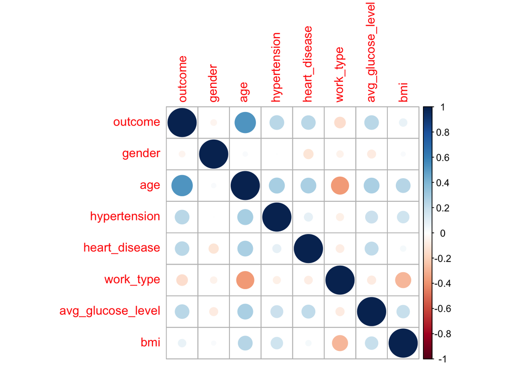

```r
corrplot(cor(stroke[, c(8,1:7)]))
```

Make outcome to be factor type and create x and y variables

```r
stroke$outcome <- factor(stroke$outcome)
# preparing the inputs
x <- model.matrix(outcome ~ . - 1, data = stroke)
y <- stroke$outcome
```

### 3. A Bayesian Logistic Regression

A Bayesian logistic regression model can be estimated using the stan_glm function. Here we’ll use a Student t prior with 7 degrees of freedom and a scale of 2.5, which, as discussed above, is a reasonable default prior when coefficients should be close to zero but have some chance of being large.

```r
t_prior =  student_t(df = 7, location = 0, scale = 2.5)
post1 =  stan_glm(outcome ~ ., data = stroke,
                 family = binomial(link = "logit"),
                 prior = t_prior, prior_intercept = t_prior, QR=TRUE,
                 seed = SEED)
```

$stan_glm$ returns the posterior distribution for the parameters describing the uncertainty related to unknown parameter values:

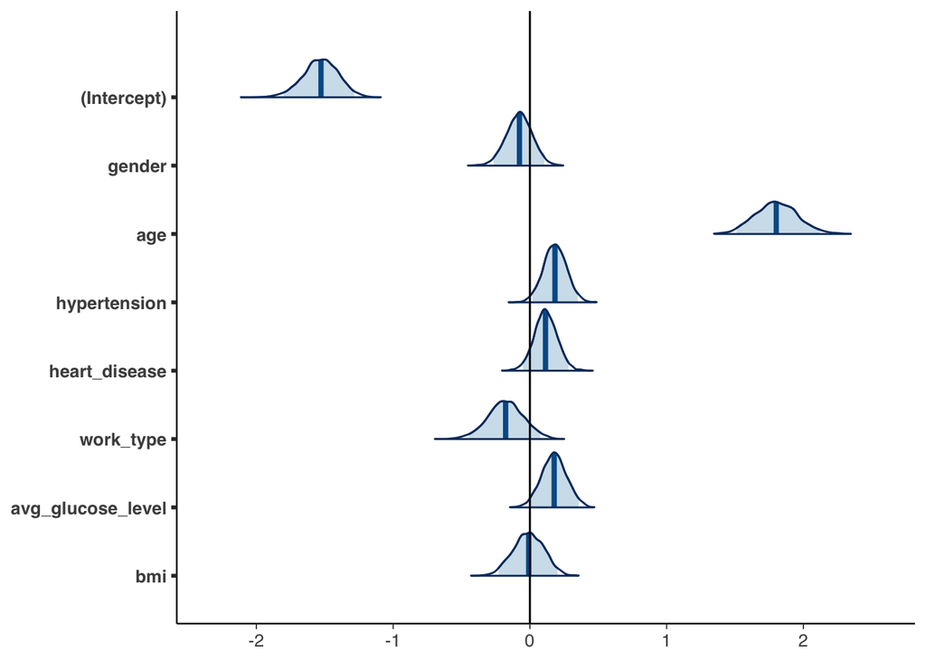

```r
pplot= plot(post1, "areas", prob = 0.95, prob_outer = 1)
pplot+ geom_vline(xintercept = 0)
```

We can extract corresponding posterior median estimates using ‘coef’ function and to get a sense for the uncertainty in our estimates we can use the posterior_interval function to get Bayesian uncertainty intervals. The uncertainty intervals are computed by finding the relevant quantiles of the draws from the posterior distribution. For example, to compute median and 90% intervals we use:

```r
round(coef(post1), 2)
```

```
##       (Intercept)            gender               age      hypertension
##             -1.53             -0.08              1.80              0.18
##     heart_disease         work_type avg_glucose_level               bmi
##              0.11             -0.18              0.18             -0.01
```

```r
round(posterior_interval(post1, prob = 0.9), 2)
```

```
##                      5%   95%
## (Intercept)       -1.75 -1.33
## gender            -0.24  0.08
## age                1.55  2.06
## hypertension       0.04  0.32
## heart_disease     -0.02  0.25
## work_type         -0.40  0.04
## avg_glucose_level  0.02  0.33
## bmi               -0.20  0.17
```

### 3.1 Leave-one-out cross-validation

rstanarm supports loo package which implements fast Pareto smoothed leave-one-out cross-validation (PSIS-LOO) to compute expected log predictive density (elpd):

```r
(loo1 =  loo(post1, save_psis = TRUE))
```

```
##
## Computed from 4000 by 830 log-likelihood matrix
##
##          Estimate   SE
## elpd_loo   -360.1 16.2
## p_loo         8.4  0.6
## looic       720.2 32.4
## ------
## Monte Carlo SE of elpd_loo is 0.0.
##
## All Pareto k estimates are good (k < 0.5).
## See help('pareto-k-diagnostic') for details.
```

Above we see that PSIS-LOO result is reliable as all Pareto k estimates are small (k< 0.5). The Pareto k diagnostic estimates how far an individual leave-one-out distribution is from the full distribution. If leaving out an observation changes the posterior too much then importance sampling is not able to give reliable estimate. If k<0.5, then the corresponding component of elpd_loo is estimated with high accuracy. If 0.5<k<0.7 the accuracy is lower, but still ok. If k>0.7, then importance sampling is not able to provide useful estimate for that component/observation

For looic, lower numbers are better. What we want is to compare the looic values of other models. having same data, likelihood (and seed). https://mc-stan.org/loo/reference/loo-glossary.html

### 3.2 Comparison to a baseline model

Compute baseline result without covariates.

```r
post0 =  update(post1, formula = outcome ~ 1, QR = FALSE)
```

```r
(loo0 =  loo(post0))
```

```
##
## Computed from 4000 by 830 log-likelihood matrix
##
##          Estimate   SE
## elpd_loo   -508.0 11.2
## p_loo         1.0  0.0
## looic      1016.0 22.4
## ------
## Monte Carlo SE of elpd_loo is 0.0.
##
## All Pareto k estimates are good (k < 0.5).
## See help('pareto-k-diagnostic') for details.
```

```r
loo_compare(loo0, loo1)
```

```
##       elpd_diff se_diff
## post1    0.0       0.0
## post0 -147.9      15.3
```

Covariates contain clearly useful information for predictions.

### 3.3 Other predictive performance measures

For more easily interpretable predictive performance measures, we next compute posterior predictive probabilities and use them to compute classification error.

```r
# Predicted probabilities
linpred =  posterior_linpred(post1)
preds =  posterior_linpred(post1, transform=TRUE)
```

```
## Instead of posterior_linpred(..., transform=TRUE) please call posterior_epred(), which provides equivalent functionality.
```

```r
pred =  colMeans(preds)
pr =  as.integer(pred >= 0.5)

# posterior classification accuracy
round(mean(xor(pr,as.integer(y==0))),2)
```

```
## [1] 0.8
```

```r
# posterior balanced classification accuracy
round((mean(xor(pr[y==0]>0.5,as.integer(y[y==0])))+mean(xor(pr[y==1]<0.5,as.integer(y[y==1]))))/2,2)
```

```
## [1] 0.75
```

The predictive performance above is overoptimistic. To better estimate the predictive performance for new not yet seen data we next use leave-one-out cross-validation:

```r
# LOO predictive probabilities
ploo=E_loo(preds, loo1$psis_object, type="mean", log_ratios = -log_lik(post1))$value
# LOO classification accuracy
round(mean(xor(ploo>0.5,as.integer(y==0))),2)
```

```
## [1] 0.79
```

```r
# LOO balanced classification accuracy
round((mean(xor(ploo[y==0]>0.5,as.integer(y[y==0])))+mean(xor(ploo[y==1]<0.5,as.integer(y[y==1]))))/2,2)
```

```
## [1] 0.74
```

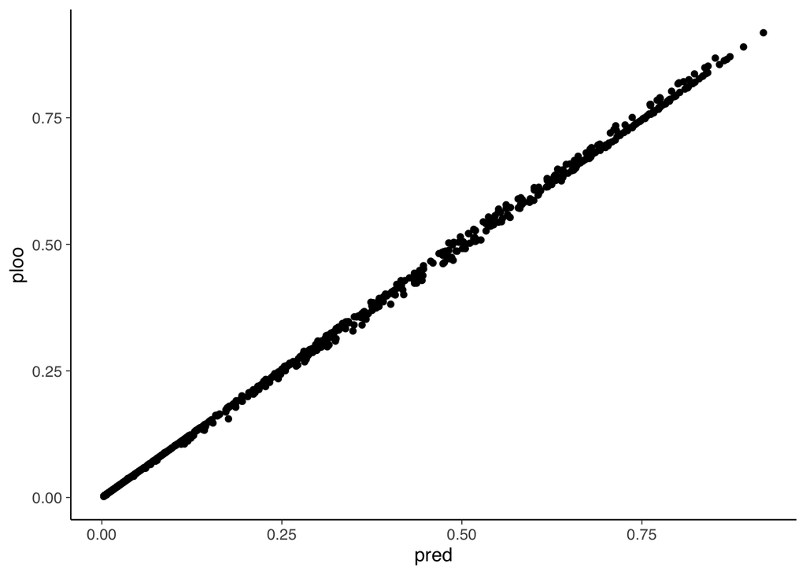

```r
qplot(pred, ploo)
```

### 3.4 Calibration of Predictions

We can also examine calibration of the posterior and LOO predictive probabilities compared to observed binned event rates. We sort the predicted probabilities in ascending order, bin the corresponding binary observations and plot the mean and uncertainty interval based on binomial distribution.

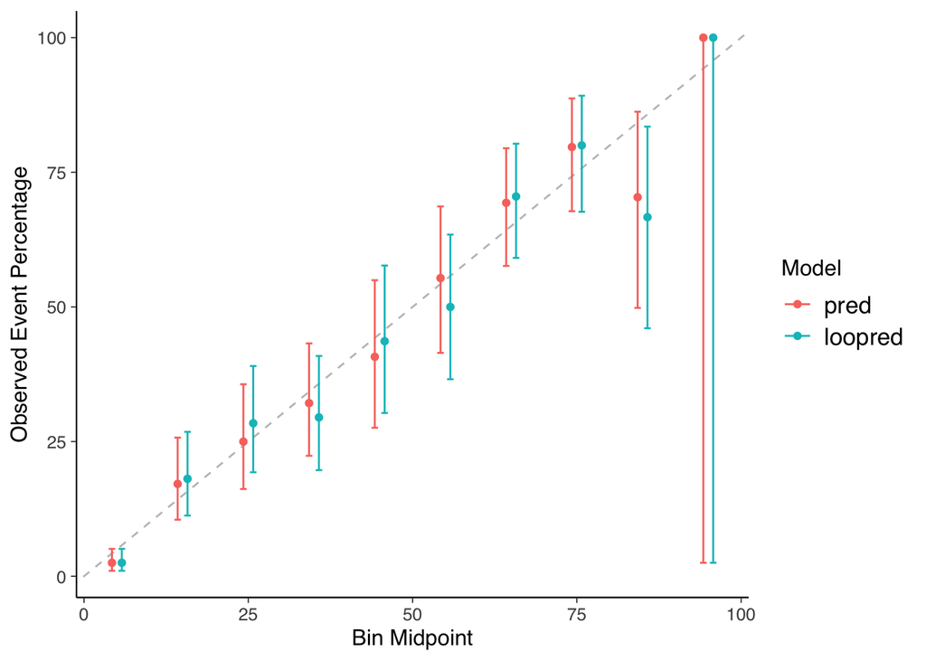

```r
calPlotData= calibration(y ~ pred + loopred,
                         data = data.frame(pred=pred,loopred=ploo,y=y),
                         cuts=10, class="1")
ggplot(calPlotData, auto.key = list(columns = 2))
```

The above calibration plot is using independent bins for the observations. The following uses a spline fit for smoothing (with narrower uncertainties).

```r
library(splines)
library(MASS)
```

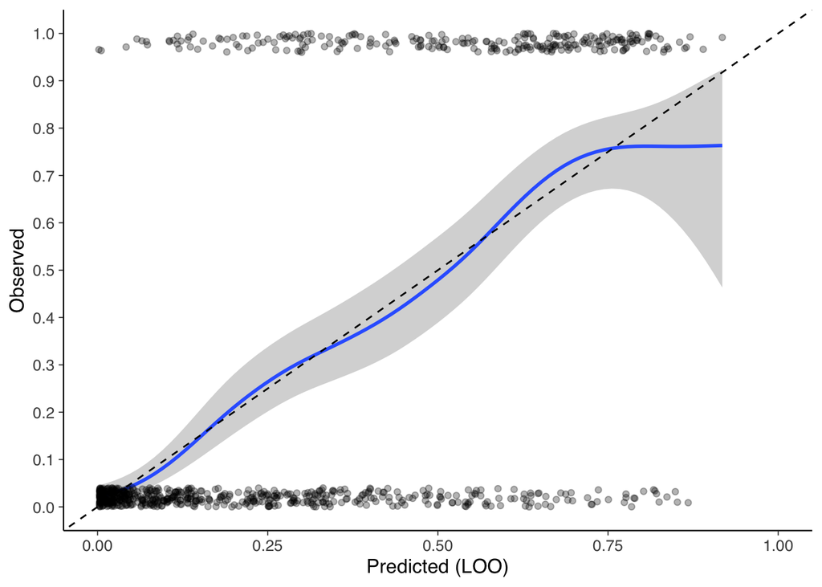

```r
ggplot(data = data.frame(pred=pred,loopred=ploo,y=as.numeric(y)-1), aes(x=loopred, y=y)) +
  stat_smooth(method='gam', formula = y ~ s(x, k=20), method.args = list(family = "binomial")) +
  geom_abline(linetype = 'dashed') +
  labs(x = "Predicted (LOO)", y = "Observed") +
  geom_jitter(aes(x=loopred, y=y*0.96+0.02), height=0.02, width=0, alpha=0.3) +
  scale_y_continuous(breaks=seq(0,1,by=0.1), limits=c(0,1)) +
  xlim(c(0,1))
```

### 4 Alternative horseshoe prior on weights.

In this example, with n>>p the difference is small, and thus we don’t expect much difference with a different prior and regularized horseshoe prior is usually more useful for n<p.

The global scale parameter for horseshoe prior is chosen as recommended by Piironen and Vehtari (2017).

```r
p0 =  2 # prior guess for the number of relevant variables
tau0 =  p0/(p-p0) * 1/sqrt(n)
hs_prior =  hs(df=1, global_df=1, global_scale=tau0)
t_prior =  student_t(df = 7, location = 0, scale = 2.5)
post2 =  stan_glm(outcome ~ ., data = stroke,
                 family = binomial(link = "logit"),
                 prior = hs_prior, prior_intercept = t_prior,
                 seed = SEED, adapt_delta = 0.9)
```

We see that the regularized horseshoe prior has shrunk the posterior distribution of irrelevant features closer to zero, without affecting the posterior distribution of the relevant features.

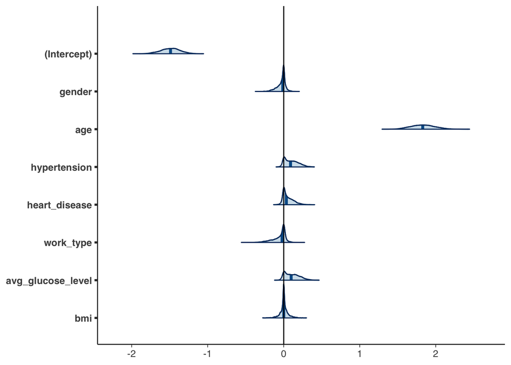

```r
pplot =  plot(post2, "areas", prob = 0.95, prob_outer = 1)
pplot + geom_vline(xintercept = 0)
```

```r
round(coef(post2), 2)
```

```
##       (Intercept)            gender               age      hypertension
##             -1.49             -0.01              1.83              0.09
##     heart_disease         work_type avg_glucose_level               bmi
##              0.03             -0.02              0.10              0.00
```

```r
round(posterior_interval(post2, prob = 0.9), 2)
```

```
##                      5%   95%
## (Intercept)       -1.71 -1.29
## gender            -0.15  0.04
## age                1.58  2.09
## hypertension      -0.01  0.26
## heart_disease     -0.02  0.19
## work_type         -0.24  0.04
## avg_glucose_level -0.01  0.28
## bmi               -0.09  0.10
```

```r
(loo2 =  loo(post2))
```

```
##
## Computed from 4000 by 830 log-likelihood matrix
##
##          Estimate   SE
## elpd_loo   -360.2 15.5
## p_loo         6.5  0.4
## looic       720.3 30.9
## ------
## Monte Carlo SE of elpd_loo is 0.0.
##
## All Pareto k estimates are good (k < 0.5).
## See help('pareto-k-diagnostic') for details.
```

```r
loo_compare(loo1, loo2)
```

```
##       elpd_diff se_diff
## post1  0.0       0.0
## post2 -0.1       2.1
```